# Practical Machine Learning Project

lespejos

September 24, 2015

# Summary

Using wearable devices it is possible to record personal activity. The large amount of data recorded need to be analyzed to take full advantage of these devices. Machine learning algorithms can be used to perform these analysis. In this project, I used data from wearable accelerometers (on belt, forearm, arm, and dumbbell) in 6 participants. Participants were asked to perform barbell lifts correctly and incorrectly in 5 different ways. The goal of this project is to predict the manner in which they did the exercise by using machine learning. The results indicated that the Random Forest model correctly predict whether barbell lifts were performed correctly when weareable devices are used.

# Data

In this step, I will download the training and testing files and read the tables as objects in R.

```r
library(caret)
```

```r
if (!file.exists("PML.project")){
    dir.create("PML.project")
}
#Download the files
url.training <- "https://d396qusza40orc.cloudfront.net/predmachlearn/pml-training.csv"
download.file(url=url.training, destfile="./PML.project/pml-training.csv")
url.testing <- "https://d396qusza40orc.cloudfront.net/predmachlearn/pml-testing.csv"
download.file(url=url.testing, destfile="./PML.project/pml-testing.csv")
downloadedate<-date()
downloadedate
```

```
## [1] "Thu Sep 24 20:13:17 2015"
```

```r
#Read tables
train <- read.csv("./PML.project/pml-training.csv", na.strings=c("NA","", "#DIV/0!"))
test <- read.csv("./PML.project/pml-testing.csv", na.strings=c("NA","", "#DIV/0!"))
#str(train)
#str(test)
```

# Data cleaning

In this step I cleaned the data set, leaving only variables that can be considered as predictors. I first deleted all the NAs observations. Then I deleted variables that are not associated to the objective of the project and cannot be as candidates for predictions. Finally I checked whether any of the remained variables have near zero variance.

```r
#delete NAs from train and test files
NAcoltrain <- apply(train,2,function(x) {sum(is.na(x))})
trainclean <- train[,which(NAcoltrain == 0)]

NAcoltest <- apply(test,2,function(x) {sum(is.na(x))})
testclean <- test[,which(NAcoltest == 0)]
#str(trainclean)
#str(testclean)

#delete identification variables and variables that "SEEMED"" to be not related to the outcome:
#(X, user_name, raw_timestamp_part_1, raw_timestamp_part_2, cvtd_timestamp, new_window, num_window)
#I could not find an explanation of these variables so I only left variables associated to belt, arm, dumbbell and forearm.
trainclean <- trainclean[-c(1:7)]
testclean <- testclean[-c(1:7)]

#names(trainclean)
#names(testclean)

#Evaluate the presence of near zero variance of the variables
traincleanNZV <- nearZeroVar(trainclean,saveMetrics=TRUE)
sum(traincleanNZV$nzv==TRUE)
```

```
## [1] 0
```

```r
testcleanNZV <- nearZeroVar(testclean,saveMetrics=TRUE)
sum(testcleanNZV$nzv==TRUE)
```

```
## [1] 0
```

None of the variables have near zero variance. All the remaining variables can be used and they can be considered predictors.

# Divide the data set in training and testing files

In this step I divide the cleaned train data set into a training (50%) and testing (50%) sets. training will be used to train the model and testing will be used to evaluate the fit of the model.

```r
inTrain <- createDataPartition(y = trainclean$classe, p=1/2, list=FALSE)
training <- trainclean[inTrain,]
testing <-trainclean[-inTrain,]
dim(training); dim(testing)
```

```
## [1] 9812   53
```

```
## [1] 9810   53
```

```r
#str(training); str(testing)
```

# Plotting predictors

In this step, I used the training set to visually evaluate the association of the variables with the classe variable.

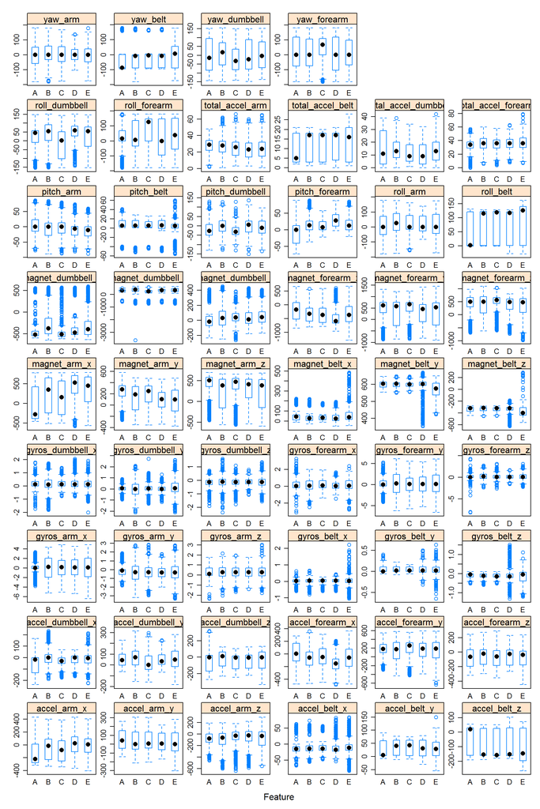

```r
featurePlot(x = training[, 1:52],
                  y=training[,53],
                  plot = "box",
                  ## Pass in options to bwplot()
                  scales=list(x=list(relation="free"), y=list(relation="free")),
                  auto.key = list(columns = 5))
```

**Figure 1. Box-plot of predictors and classe variables**

# Model training

```r
set.seed(1234)
model <- train(classe~., method="rf", data=training)
model
```

```
## Random Forest
##
## 9812 samples
##   52 predictor
##    5 classes: 'A', 'B', 'C', 'D', 'E'
##
## No pre-processing
## Resampling: Bootstrapped (25 reps)
## Summary of sample sizes: 9812, 9812, 9812, 9812, 9812, 9812, ...
## Resampling results across tuning parameters:
##
##   mtry  Accuracy   Kappa      Accuracy SD  Kappa SD
##    2    0.9815461  0.9766407  0.003108933  0.003934322
##   27    0.9833079  0.9788743  0.002601967  0.003287411
##   52    0.9740474  0.9671505  0.004697647  0.005958016
##
## Accuracy was used to select the optimal model using  the largest value.
## The final value used for the model was mtry = 27.
```

```r
model$finalModel
```

```
##
## Call:
##  randomForest(x = x, y = y, mtry = param$mtry)
##                Type of random forest: classification
##                      Number of trees: 500
## No. of variables tried at each split: 27
##
##         OOB estimate of  error rate: 1.1%
## Confusion matrix:
##      A    B    C    D    E class.error
## A 2784    3    1    1    1 0.002150538
## B   28 1862    7    2    0 0.019483939
## C    0   16 1689    6    0 0.012857978
## D    0    0   31 1575    2 0.020522388
## E    1    1    3    5 1794 0.005543237
```

# Model testing, cross-validation

In this step, I used the testing set to cross-validate the efficacy of the Random Forest model to correctly differentiate the different classe.

```r
predtest <- predict(model, testing)
confusionMatrix(predtest, testing$classe)
```

```
## Confusion Matrix and Statistics
##
##           Reference
## Prediction    A    B    C    D    E
##          A 2784   26    0    0    0
##          B    5 1852    8    2    0
##          C    1   20 1685   24    3
##          D    0    0   18 1582    7
##          E    0    0    0    0 1793
##
## Overall Statistics
##
##                Accuracy : 0.9884
##                  95% CI : (0.9861, 0.9904)
##     No Information Rate : 0.2844
##     P-Value [Acc > NIR] : < 2.2e-16
##
##                   Kappa : 0.9853
##  Mcnemar's Test P-Value : NA
##
## Statistics by Class:
##
##                      Class: A Class: B Class: C Class: D Class: E
## Sensitivity            0.9978   0.9758   0.9848   0.9838   0.9945
## Specificity            0.9963   0.9981   0.9941   0.9970   1.0000
## Pos Pred Value         0.9907   0.9920   0.9723   0.9844   1.0000
## Neg Pred Value         0.9991   0.9942   0.9968   0.9968   0.9988
## Prevalence             0.2844   0.1935   0.1744   0.1639   0.1838
## Detection Rate         0.2838   0.1888   0.1718   0.1613   0.1828
## Detection Prevalence   0.2864   0.1903   0.1767   0.1638   0.1828
## Balanced Accuracy      0.9971   0.9869   0.9894   0.9904   0.9972
```

The Random Forest model correctly differentiate the different classe with an accuracy of **98.8% (95% CI: 98.6- 99.0%)**. I think the model had a very good performance with an error rate of **1.16%**.

# Model predictions and submission file of predictions

Finally I used the model to compute classe predictions based in a new set of data

```r
# prediction of the test data set provided by the instructor.
predictions <- predict(model, testclean)

#code to create 20 single files to submmit the results.
pml_write_files = function(x){
  n = length(x)
  for(i in 1:n){
    filename = paste0("problem_id_",i,".txt")
    write.table(x[i],file=filename,quote=FALSE,row.names=FALSE,col.names=FALSE)
  }
}
pml_write_files(predictions)
```

## Conclusions

The Random Forest model correctly predict the classe variable. These wearable devices may be useful to make sure that barbell lifts were performed correctly.

## Reference

Velloso, E.; Bulling, A.; Gellersen, H.; Ugulino, W.; Fuks, H. Qualitative Activity Recognition of Weight Lifting Exercises. Proceedings of 4th Augmented Human (AH) International Conference in cooperation with ACM SIGCHI (Augmented Human’13) . Stuttgart, Germany: ACM SIGCHI, 2013.